# STEP 1:

# EXPLORATORY DATA ANALYSIS

# STEP 9:

# Introduction to EDA and Data Exploration

```python
# Check the structure of the dataset
print("Dataset Info:")
df.info()
```

```
Dataset Info:
<class 'pandas.core.frame.DataFrame'>
RangeIndex: 4340 entries, 0 to 4339
Data columns (total 10 columns):
 #   Column         Non-Null Count  Dtype
---  ------         --------------  -----
 0   name           4340 non-null   object
 1   year           4340 non-null   int64
 2   selling_price  4340 non-null   float64
 3   km_driven      4340 non-null   int64
 4   fuel           4340 non-null   object
 5   seller_type    4340 non-null   object
 6   transmission   4340 non-null   object
 7   car_age        4340 non-null   int64
 8   price_per_km   4340 non-null   float64
 9   km_per_year    4340 non-null   float64
dtypes: float64(3), int64(3), object(4)
memory usage: 339.2+ KB
```

```python
# summary statistics for numerical columns
print("Summary Statistics: \n")
display(df.describe())
```

```
Summary Statistics:
```

|  | year | selling_price | km_driven | car_age | price_per_km | km_per_year |
| --- | --- | --- | --- | --- | --- | --- |
| count | 4340.000000 | 4.340000e+03 | 4340.000000 | 4340.000000 | 4340.000000 | 4340.000000 |
| mean | 2013.090783 | 5.041773e+05 | 66215.777419 | 11.909217 | 88.014870 | 5523.613661 |
| std | 4.215344 | 5.785158e+05 | 46644.102194 | 4.215344 | 3801.519927 | 3594.452860 |
| min | 1992.000000 | 2.000000e+04 | 1.000000 | 5.000000 | 0.250000 | 0.090909 |
| 25% | 2011.000000 | 2.100000e+05 | 35000.000000 | 9.000000 | 2.629934 | 3181.818182 |
| 50% | 2014.000000 | 3.500000e+05 | 60000.000000 | 11.000000 | 6.000000 | 5000.000000 |
| 75% | 2016.000000 | 6.000000e+05 | 90000.000000 | 14.000000 | 15.552441 | 7058.823529 |
| max | 2020.000000 | 8.900000e+06 | 806599.000000 | 33.000000 | 250000.000000 | 62222.222222 |

```python
# Checking for missing values
print("\nMissing Values in Each Column:")
print(df.isnull().sum())
```

```
Missing Values in Each Column:
name             0
year             0
selling_price    0
km_driven        0
fuel             0
seller_type      0
transmission     0
car_age          0
price_per_km     0
km_per_year      0
dtype: int64
```

# STEP 10

# Handling Duplicates

```python
#Counting number of duplicated rows
duplicate_count = df.duplicated().sum()
print("Number of duplicate rows: ",duplicate_count)
```

```
Number of duplicate rows:  767
```

```python
#Viewing Suplicated rows
print("duplicate entries:")
display(df[df.duplicated()].head())
```

```
duplicate entries:
```

|  | name | year | selling_price | km_driven | fuel | seller_type | transmission | car_age | price_per_km | km_per_year |
| --- | --- | --- | --- | --- | --- | --- | --- | --- | --- | --- |
| 13 | Maruti 800 AC | 2007 | 66000.0 | 70000 | Petrol | Individual | Manual | 18 | 0.942857 | 3888.888889 |
| 14 | Maruti Wagon R LXI Minor | 2007 | 135000.0 | 50000 | Petrol | Individual | Manual | 18 | 2.700000 | 2777.777778 |
| 15 | Hyundai Verna 1.6 SX | 2012 | 600000.0 | 100000 | Diesel | Individual | Manual | 13 | 6.000000 | 7692.307692 |
| 16 | Datsun RediGO T Option | 2017 | 250000.0 | 46000 | Petrol | Individual | Manual | 8 | 5.434783 | 5750.000000 |
| 17 | Honda Amaze VX i-DTEC | 2014 | 450000.0 | 141000 | Diesel | Individual | Manual | 11 | 3.191489 | 12818.181818 |

```python
# Dataset Shape before dropping duplicates
print("Dataset Shape before dropping duplicates\n")
df.shape
```

```
Dataset Shape before dropping duplicates
```

```
(4340, 10)
```

```python
# Dataset Shape after dropping duplicates
df.drop_duplicates(inplace=True)
print("Dataset Shape after dropping duplicates\n")
df.shape
```

```
Dataset Shape after dropping duplicates
```

```
(3573, 10)
```

# STEP 11

# HANDLING MISSING VALUES

```python
#Checking Missing Values
print("Missing values in each column:")
print(df.isnull().sum())
```

```
Missing values in each column:
name             0
year             0
selling_price    0
km_driven        0
fuel             0
seller_type      0
transmission     0
car_age          0
price_per_km     0
km_per_year      0
dtype: int64
```

# We checked for missing values using `df.isnull().sum()` and found that **no missing values** exist in any column of the dataset.

# This indicates that the data is already complete and ready for further analysis.

# STEP 12

# HANDLING OUTLIERS

```python
import seaborn as sns
import matplotlib.pyplot as plt

#HANDLING OUTLIERS USING IQR METHOD
#Calculating Q1, Q3 and IQR for 'selling_price'

q1 = df['selling_price'].quantile(0.25)
q3 = df['selling_price'].quantile(0.75)
iqr = q3 - q1

#Defining lower and Upper limits
lower_cutoff = q1 - 1.5 * iqr
upper_cutoff = q3 + 1.5 * iqr

print("Lower Cutoff:", lower_cutoff)
print("Upper Cutoff:", upper_cutoff)
```

```
Lower Cutoff: -400000.0
Upper Cutoff: 1200000.0
```

```python
#Checking Outliers
p0 = df['selling_price'].min()
p100 = df['selling_price'].max()
print(f"Min (P0): {p0}, Max (P100): {p100}")
```

```
Min (P0): 20000.0, Max (P100): 8900000.0
```

```python
if lower_cutoff > p0:
    print("There are lower outliers")
else:
    print("No lower outliers")

if upper_cutoff < p100:
    print("There are upper outliers")
else:
    print("No upper outliers")
```

```
No lower outliers
There are upper outliers
```

```
Boxplot BEFORE clipping:
```

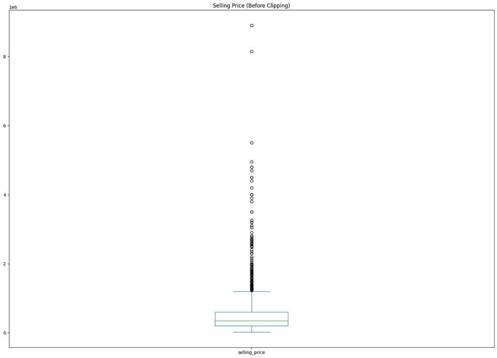

```python
#Checking using Boxplot
print("Boxplot BEFORE clipping:")
df.selling_price.plot(kind='box',figsize=(20,14),title='Selling Price (Before Clipping)')
```

WE CAN NOTICE THE OUTLIERS ON THE UPPER CUT OFF

NOW CLIPPING THE UPPER OUTLIERS USING WINSORIZATION

```python
df['selling_price'] = df['selling_price'].clip(upper=upper_cutoff)
```

```
Boxplot AFTER clipping:
```

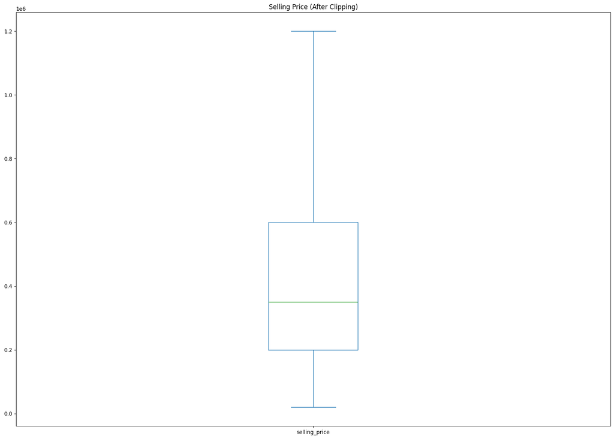

```python
#Boxplotting after clipping
print("Boxplot AFTER clipping:")
df['selling_price'].plot(kind='box', figsize=(20, 14), title='Selling Price (After Clipping)')
```

WE CAN NOTICE THAT THE UPPER OUTLIERS ARE CLIPPED